# Homework 7 Solutions

Alexandra Chronopoulou

## Part I: Practice Questions

### Problem 1

Using the data set with as the response and the other variables as predictors. Implement the following variable select methods to determine the best model:

```r
library(faraway)
library(leaps)
data(teengamb)
head(teengamb)
```

```
##   sex status income verbal gamble
## 1   1     51   2.00      8    0.0
## 2   1     28   2.50      8    0.0
## 3   1     37   2.00      6    0.0
## 4   1     28   7.00      4    7.3
## 5   1     65   2.00      8   19.6
## 6   1     61   3.47      6    0.1
```

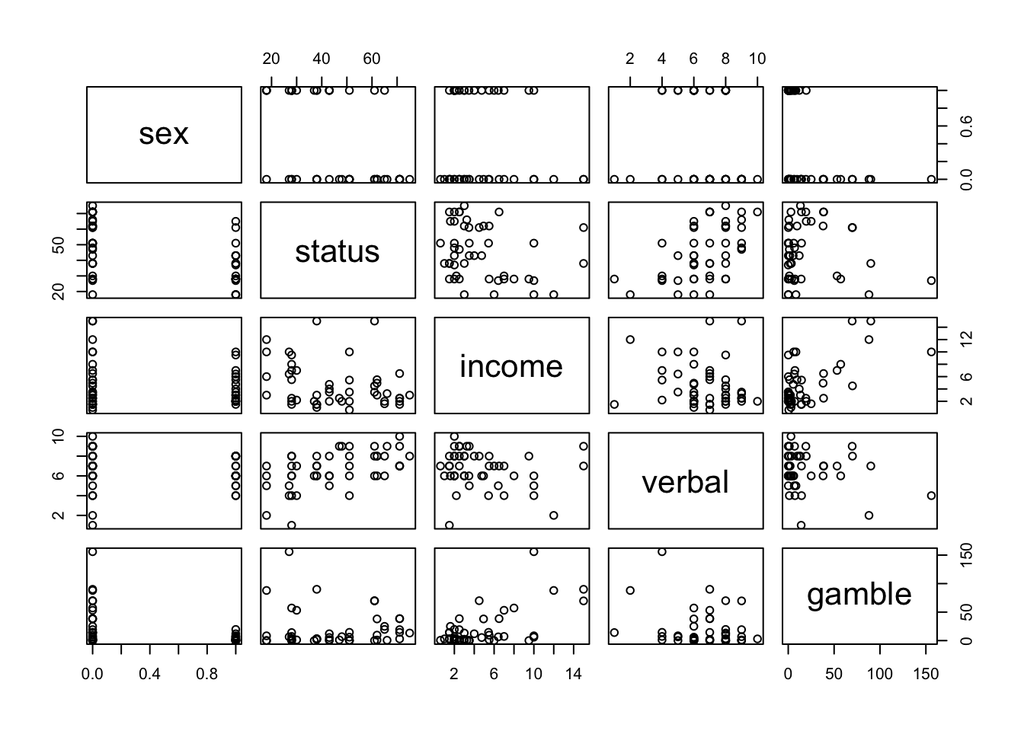

```r
plot(teengamb)
```

```r
modteen1<-lm(gamble~.,data=teengamb)
summary(modteen1)
```

```
##
## Call:
## lm(formula = gamble ~ ., data = teengamb)
##
## Residuals:
##     Min      1Q  Median      3Q     Max
## -51.082 -11.320  -1.451   9.452  94.252
##
## Coefficients:
##              Estimate Std. Error t value Pr(>|t|)
## (Intercept)  22.55565   17.19680   1.312   0.1968
## sex         -22.11833    8.21111  -2.694   0.0101 *
## status        0.05223    0.28111   0.186   0.8535
## income        4.96198    1.02539   4.839 1.79e-05 ***
## verbal       -2.95949    2.17215  -1.362   0.1803
## ---
## Signif. codes:  0 '***' 0.001 '**' 0.01 '*' 0.05 '.' 0.1 ' ' 1
##
## Residual standard error: 22.69 on 42 degrees of freedom
## Multiple R-squared:  0.5267, Adjusted R-squared:  0.4816
## F-statistic: 11.69 on 4 and 42 DF,  p-value: 1.815e-06
```

1. Backward Elimination

```r
modteen1<-lm(gamble~.,data=teengamb)
summary(modteen1)
```

```
##
## Call:
## lm(formula = gamble ~ ., data = teengamb)
##
## Residuals:
##     Min      1Q  Median      3Q     Max
## -51.082 -11.320  -1.451   9.452  94.252
##
## Coefficients:
##              Estimate Std. Error t value Pr(>|t|)
## (Intercept)  22.55565   17.19680   1.312   0.1968
## sex         -22.11833    8.21111  -2.694   0.0101 *
## status        0.05223    0.28111   0.186   0.8535
## income        4.96198    1.02539   4.839 1.79e-05 ***
## verbal       -2.95949    2.17215  -1.362   0.1803
## ---
## Signif. codes:  0 '***' 0.001 '**' 0.01 '*' 0.05 '.' 0.1 ' ' 1
##
## Residual standard error: 22.69 on 42 degrees of freedom
## Multiple R-squared:  0.5267, Adjusted R-squared:  0.4816
## F-statistic: 11.69 on 4 and 42 DF,  p-value: 1.815e-06
```

```r
modteen2<-lm(gamble~sex+income+verbal,data=teengamb)
summary(modteen2)
```

```
##
## Call:
## lm(formula = gamble ~ sex + income + verbal, data = teengamb)
##
## Residuals:
##     Min      1Q  Median      3Q     Max
## -50.639 -11.765  -1.594   9.305  93.867
##
## Coefficients:
##             Estimate Std. Error t value Pr(>|t|)
## (Intercept)  24.1390    14.7686   1.634   0.1095
## sex         -22.9602     6.7706  -3.391   0.0015 **
## income        4.8981     0.9551   5.128 6.64e-06 ***
## verbal       -2.7468     1.8253  -1.505   0.1397
## ---
## Signif. codes:  0 '***' 0.001 '**' 0.01 '*' 0.05 '.' 0.1 ' ' 1
##
## Residual standard error: 22.43 on 43 degrees of freedom
## Multiple R-squared:  0.5263, Adjusted R-squared:  0.4933
## F-statistic: 15.93 on 3 and 43 DF,  p-value: 4.148e-07
```

```r
modteen3<-lm(gamble~sex+income,data=teengamb)
summary(modteen3)
```

```
##
## Call:
## lm(formula = gamble ~ sex + income, data = teengamb)
##
## Residuals:
##     Min      1Q  Median      3Q     Max
## -49.757 -11.649   0.844   8.659 100.243
##
## Coefficients:
##             Estimate Std. Error t value Pr(>|t|)
## (Intercept)    4.041      6.394   0.632  0.53070
## sex          -21.634      6.809  -3.177  0.00272 **
## income         5.172      0.951   5.438 2.24e-06 ***
## ---
## Signif. codes:  0 '***' 0.001 '**' 0.01 '*' 0.05 '.' 0.1 ' ' 1
##
## Residual standard error: 22.75 on 44 degrees of freedom
## Multiple R-squared:  0.5014, Adjusted R-squared:  0.4787
## F-statistic: 22.12 on 2 and 44 DF,  p-value: 2.243e-07
```

```r
backmodteen1<-step(modteen1, direction="backward")
```

```
## Start:  AIC=298.18
## gamble ~ sex + status + income + verbal
##
##          Df Sum of Sq   RSS    AIC
## - status  1      17.8 21642 296.21
## <none>                21624 298.18
## - verbal  1     955.7 22580 298.21
## - sex     1    3735.8 25360 303.67
## - income  1   12056.2 33680 317.00
##
## Step:  AIC=296.21
## gamble ~ sex + income + verbal
##
##          Df Sum of Sq   RSS    AIC
## <none>                21642 296.21
## - verbal  1    1139.8 22781 296.63
## - sex     1    5787.9 27429 305.35
## - income  1   13236.1 34878 316.64
```

```r
summary(backmodteen1)
```

```
##
## Call:
## lm(formula = gamble ~ sex + income + verbal, data = teengamb)
##
## Residuals:
##     Min      1Q  Median      3Q     Max
## -50.639 -11.765  -1.594   9.305  93.867
##
## Coefficients:
##             Estimate Std. Error t value Pr(>|t|)
## (Intercept)  24.1390    14.7686   1.634   0.1095
## sex         -22.9602     6.7706  -3.391   0.0015 **
## income        4.8981     0.9551   5.128 6.64e-06 ***
## verbal       -2.7468     1.8253  -1.505   0.1397
## ---
## Signif. codes:  0 '***' 0.001 '**' 0.01 '*' 0.05 '.' 0.1 ' ' 1
##
## Residual standard error: 22.43 on 43 degrees of freedom
## Multiple R-squared:  0.5263, Adjusted R-squared:  0.4933
## F-statistic: 15.93 on 3 and 43 DF,  p-value: 4.148e-07
```

2. AIC

```r
regsubmodteen<-leaps::regsubsets(gamble~.,data=teengamb)
rs<-summary(regsubmodteen)
rs$which
```

```
##   (Intercept)   sex status income verbal
## 1        TRUE FALSE  FALSE   TRUE  FALSE
## 2        TRUE  TRUE  FALSE   TRUE  FALSE
## 3        TRUE  TRUE  FALSE   TRUE   TRUE
## 4        TRUE  TRUE   TRUE   TRUE   TRUE
```

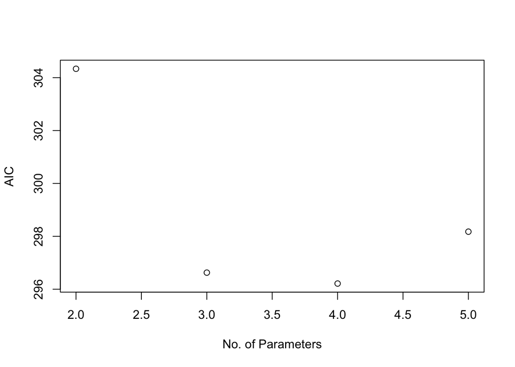

```r
n=dim(teengamb)[1];
msize = 2:5
## check msize values here


Aic = n*log(rs$rss/n) + 2*msize
plot(msize, Aic, xlab="No. of Parameters", ylab = "AIC")
```

```r
rs$which[which.min(Aic),]
```

```
## (Intercept)         sex      status      income      verbal
##        TRUE        TRUE       FALSE        TRUE        TRUE
```

3. Adjusted R-squared

```r
rs$adjr2
```

```
## [1] 0.3733570 0.4787240 0.4932879 0.4816495
```

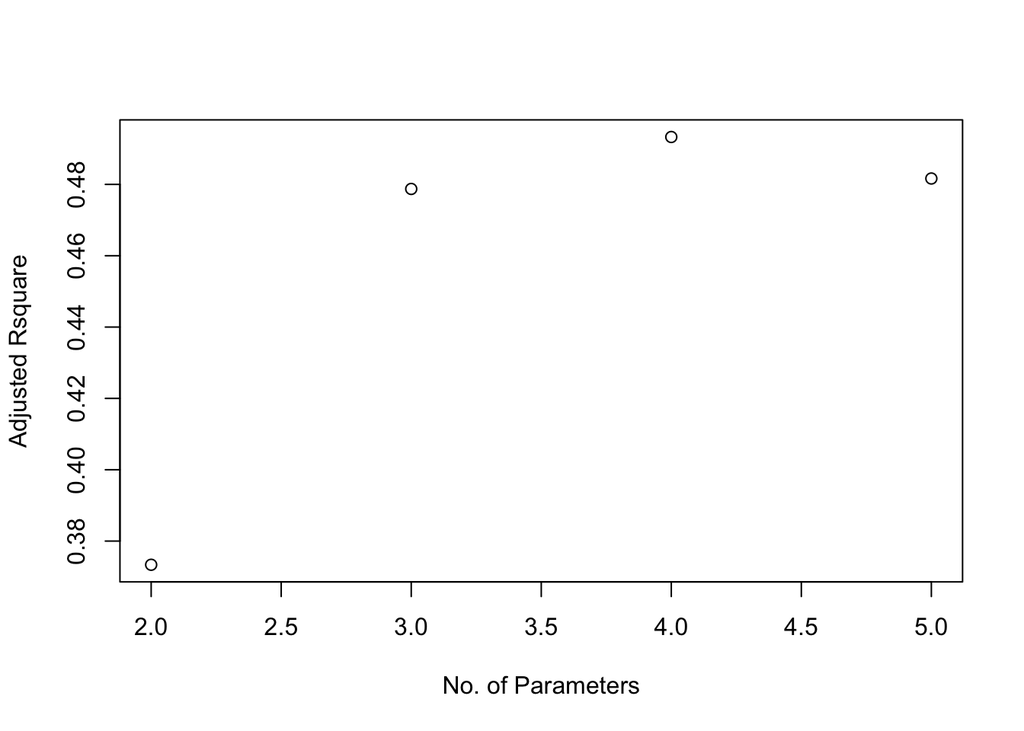

```r
plot(msize, rs$adjr2, xlab="No. of Parameters", ylab = "Adjusted Rsquare")
```

```r
rs$which[which.max(rs$adjr2),]
```

```
## (Intercept)         sex      status      income      verbal
##        TRUE        TRUE       FALSE        TRUE        TRUE
```

4. Mallow’s Cp

```r
rs$cp
```

```
## [1] 11.401283  3.248323  3.034526  5.000000
```

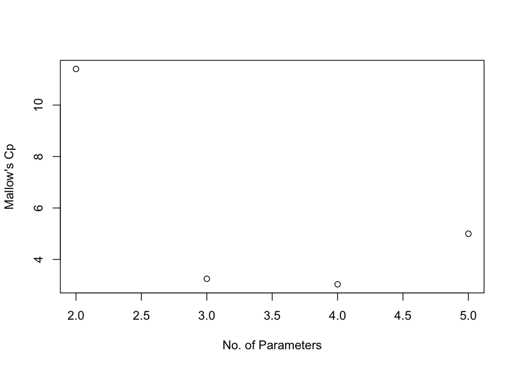

```r
plot(msize, rs$cp, xlab="No. of Parameters", ylab = "Mallow's Cp")
```

```r
rs$which[which.min(rs$cp),]
```

```
## (Intercept)         sex      status      income      verbal
##        TRUE        TRUE       FALSE        TRUE        TRUE
```

### Problem 2

Using the data set with as the response and the other variables as predictors. Investigate the possibility of interactions between and the other predictors.

```r
library(faraway)
library(leaps)
data(teengamb)
head(teengamb)
```

```
##   sex status income verbal gamble
## 1   1     51   2.00      8    0.0
## 2   1     28   2.50      8    0.0
## 3   1     37   2.00      6    0.0
## 4   1     28   7.00      4    7.3
## 5   1     65   2.00      8   19.6
## 6   1     61   3.47      6    0.1
```

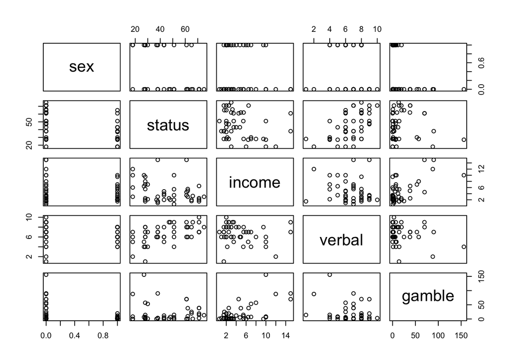

```r
plot(teengamb)
```

```r
interactions = lm(gamble ~ sex+status +income +verbal+ sex:status+ sex:income+ sex:verbal, data=teengamb )
summary(interactions)
```

```
##
## Call:
## lm(formula = gamble ~ sex + status + income + verbal + sex:status +
##     sex:income + sex:verbal, data = teengamb)
##
## Residuals:
##     Min      1Q  Median      3Q     Max
## -56.654  -7.589  -1.016   3.323  83.903
##
## Coefficients:
##             Estimate Std. Error t value Pr(>|t|)
## (Intercept)  27.6354    17.6218   1.568   0.1249
## sex         -33.0132    35.0530  -0.942   0.3521
## status       -0.1456     0.3316  -0.439   0.6631
## income        6.0291     1.0538   5.721 1.26e-06 ***
## verbal       -2.9748     2.4265  -1.226   0.2276
## sex:status    0.3529     0.5492   0.643   0.5243
## sex:income   -5.3478     2.4244  -2.206   0.0334 *
## sex:verbal    2.8355     4.5973   0.617   0.5410
## ---
## Signif. codes:  0 '***' 0.001 '**' 0.01 '*' 0.05 '.' 0.1 ' ' 1
##
## Residual standard error: 20.98 on 39 degrees of freedom
## Multiple R-squared:  0.6243, Adjusted R-squared:  0.5569
## F-statistic:  9.26 on 7 and 39 DF,  p-value: 1.06e-06
```

```r
interactions2 = lm(gamble ~ sex+status +income +verbal+  sex:income, data=teengamb )
summary(interactions2)
```

```
##
## Call:
## lm(formula = gamble ~ sex + status + income + verbal + sex:income,
##     data = teengamb)
##
## Residuals:
##     Min      1Q  Median      3Q     Max
## -57.109  -6.162  -0.938   2.267  86.503
##
## Coefficients:
##             Estimate Std. Error t value Pr(>|t|)
## (Intercept) 19.25943   15.79635   1.219  0.22972
## sex          4.06362   11.51612   0.353  0.72600
## status      -0.04876    0.25978  -0.188  0.85203
## income       6.19885    1.02591   6.042 3.77e-07 ***
## verbal      -2.60864    1.99386  -1.308  0.19805
## sex:income  -6.43683    2.14337  -3.003  0.00454 **
## ---
## Signif. codes:  0 '***' 0.001 '**' 0.01 '*' 0.05 '.' 0.1 ' ' 1
##
## Residual standard error: 20.79 on 41 degrees of freedom
## Multiple R-squared:  0.6121, Adjusted R-squared:  0.5647
## F-statistic: 12.94 on 5 and 41 DF,  p-value: 1.417e-07
```

```r
anova(interactions2, interactions)
```

```
## Analysis of Variance Table
##
## Model 1: gamble ~ sex + status + income + verbal + sex:income
## Model 2: gamble ~ sex + status + income + verbal + sex:status + sex:income +
##     sex:verbal
##   Res.Df   RSS Df Sum of Sq      F Pr(>F)
## 1     41 17725
## 2     39 17164  2    561.29 0.6377 0.5339
```

```r
interactions3 = lm(gamble ~ sex +income +  sex:income, data=teengamb )
summary(interactions3)
```

```
##
## Call:
## lm(formula = gamble ~ sex + income + sex:income, data = teengamb)
##
## Residuals:
##     Min      1Q  Median      3Q     Max
## -56.522  -4.860  -1.790   6.273  93.478
##
## Coefficients:
##             Estimate Std. Error t value Pr(>|t|)
## (Intercept)  -2.6596     6.3164  -0.421  0.67580
## sex           5.7996    11.2003   0.518  0.60724
## income        6.5181     0.9881   6.597 4.95e-08 ***
## sex:income   -6.3432     2.1446  -2.958  0.00502 **
## ---
## Signif. codes:  0 '***' 0.001 '**' 0.01 '*' 0.05 '.' 0.1 ' ' 1
##
## Residual standard error: 20.98 on 43 degrees of freedom
## Multiple R-squared:  0.5857, Adjusted R-squared:  0.5568
## F-statistic: 20.26 on 3 and 43 DF,  p-value: 2.451e-08
```

```r
anova(interactions3)
```

```
## Analysis of Variance Table
##
## Response: gamble
##            Df  Sum Sq Mean Sq F value    Pr(>F)
## sex         1  7598.4  7598.4 17.2601 0.0001519 ***
## income      1 15309.8 15309.8 34.7767 5.159e-07 ***
## sex:income  1  3851.4  3851.4  8.7486 0.0050182 **
## Residuals  43 18929.9   440.2
## ---
## Signif. codes:  0 '***' 0.001 '**' 0.01 '*' 0.05 '.' 0.1 ' ' 1
```

## Part II: Homework Questions

### Problem 1

```r
questionnaires = read.csv("questionnaire.csv", header=TRUE, sep=",")
head(questionnaires)
```

```
##   rate color lot.size
## 1   28  blue      300
## 2   26  blue      381
## 3   31  blue      226
## 4   27  blue      350
## 5   35  blue      100
## 6   29  blue      252
```

1. State
   1. the regression line that corresponds to the blue questionnaires.
   2. the regression line that corresponds to the green questionnaires.

The full model that we fit is
$$Y = \beta_0 + \beta_1 \; size + \beta_2 \; color + \beta_3 size*color + \varepsilon$$

```r
model.full = lm(rate ~ lot.size*color, data=questionnaires)
summary(model.full)
```

```
##
## Call:
## lm(formula = rate ~ lot.size * color, data = questionnaires)
##
## Residuals:
##     Min      1Q  Median      3Q     Max
## -5.6036 -1.1694  0.3028  1.2939  4.0309
##
## Coefficients:
##                      Estimate Std. Error t value Pr(>|t|)
## (Intercept)         33.669361   2.306804  14.596 2.85e-10 ***
## lot.size            -0.019907   0.009189  -2.167   0.0468 *
## colorgreen           1.660979   3.422258   0.485   0.6344
## lot.size:colorgreen  0.002003   0.012136   0.165   0.8711
## ---
## Signif. codes:  0 '***' 0.001 '**' 0.01 '*' 0.05 '.' 0.1 ' ' 1
##
## Residual standard error: 2.467 on 15 degrees of freedom
## Multiple R-squared:   0.41,  Adjusted R-squared:  0.292
## F-statistic: 3.475 on 3 and 15 DF,  p-value: 0.04282
```

Without looking at the statistical significance of the terms, we have the following two fitted regression lines:
$$\text{Blue}: rate = 33.67 - 0.02\, size$$
$$\text{Green}: rate = (33.67+1.66) + (- 0.02 + 0.002) \,size = 35.33 - 0.018\, size$$

2. Test whether or not the interaction term is statistically significant. State the hypotheses, decision rule and conclusion.

   We want to perform the following hypothesis test:
   $$\begin{cases}
   & H_0: \beta_{3} = 0\\
   & H_{\alpha}: \beta_{3} \neq 0
   \end{cases}$$
   We can also formulate it as
   $$\begin{cases}
   & H_0: rate ~ size + color\\
   & H_{\alpha}: rate ~ size + color + size*color
   \end{cases}$$

   ```r
   model.red1 = lm(rate ~ lot.size + color, data = questionnaires)
   anova(model.red1, model.full)
   ```

   ```
   ## Analysis of Variance Table
   ##
   ## Model 1: rate ~ lot.size + color
   ## Model 2: rate ~ lot.size * color
   ##   Res.Df    RSS Df Sum of Sq      F Pr(>F)
   ## 1     16 91.458
   ## 2     15 91.293  1    0.1658 0.0272 0.8711
   ```

   Based on the p-value=0.87 we conclude that the interaction term is not statistically significant.
3. Does the response rate vary according to the questionnaire color? Justify your answer.

   Since the interaction term is not statistically significant, we can remove it from the model. So, this question essentially asks us to test for the color factor. The hypothesis formulates as follows:

   $$\begin{cases}
   & H_0: rate ~ size \\
   & H_{\alpha}: rate ~ size + color
   \end{cases}$$

```r
model.red2 = lm(rate ~ lot.size, data = questionnaires)
anova(model.red2, model.red1)
```

```
## Analysis of Variance Table
##
## Model 1: rate ~ lot.size
## Model 2: rate ~ lot.size + color
##   Res.Df     RSS Df Sum of Sq     F  Pr(>F)
## 1     17 111.511
## 2     16  91.458  1    20.052 3.508 0.07946 .
## ---
## Signif. codes:  0 '***' 0.001 '**' 0.01 '*' 0.05 '.' 0.1 ' ' 1
```

Based on the p-value=0.079 > 0.05 we conclude that the color variable is not statistically significant, and therefore the response rate does not vary significantly according to the questionnaire color.

### Problem 2

The Major League Baseball data set contains data for 322 major league players from the 1986 and 1987 seasons. We are interested in predicting the `Salary` of a player. We have available the following predictors: AtBat, Hits, HmRun, Runs, RBI, Walks, Years, CAtBat, CHits, CHmRun, CRuns, CRBI, CWalks, League, Division, PutOuts, Assists, Errors. The data set is called `Hitters` and can be found in the `ISLR` library.

```r
library(ISLR)
data(Hitters)
head(Hitters)
```

```
##                   AtBat Hits HmRun Runs RBI Walks Years CAtBat CHits CHmRun
## -Andy Allanson      293   66     1   30  29    14     1    293    66      1
## -Alan Ashby         315   81     7   24  38    39    14   3449   835     69
## -Alvin Davis        479  130    18   66  72    76     3   1624   457     63
## -Andre Dawson       496  141    20   65  78    37    11   5628  1575    225
## -Andres Galarraga   321   87    10   39  42    30     2    396   101     12
## -Alfredo Griffin    594  169     4   74  51    35    11   4408  1133     19
##                   CRuns CRBI CWalks League Division PutOuts Assists Errors
## -Andy Allanson       30   29     14      A        E     446      33     20
## -Alan Ashby         321  414    375      N        W     632      43     10
## -Alvin Davis        224  266    263      A        W     880      82     14
## -Andre Dawson       828  838    354      N        E     200      11      3
## -Andres Galarraga    48   46     33      N        E     805      40      4
## -Alfredo Griffin    501  336    194      A        W     282     421     25
##                   Salary NewLeague
## -Andy Allanson        NA         A
## -Alan Ashby        475.0         N
## -Alvin Davis       480.0         A
## -Andre Dawson      500.0         N
## -Andres Galarraga   91.5         N
## -Alfredo Griffin   750.0         A
```

```r
#Remove additional predictors
 Hitters$League = Hitters$Division = Hitters$NewLeague = NULL
```

1. What is the *optimal* number of parameters according to
   1. the adjusted $R^2$ criterion,
   2. the Mallows $C_p$ criterion,
   3. the AIC,
   4. the BIC.

   We will use the `regsubsets` function from the `leaps` library:

   ```r
   library(leaps)
   model.full = regsubsets(Salary ~ ., data = Hitters, nvmax=17)
   summary(model.full)
   ```

   ```
   ## Subset selection object
   ## Call: regsubsets.formula(Salary ~ ., data = Hitters, nvmax = 17)
   ## 16 Variables  (and intercept)
   ##         Forced in Forced out
   ## AtBat       FALSE      FALSE
   ## Hits        FALSE      FALSE
   ## HmRun       FALSE      FALSE
   ## Runs        FALSE      FALSE
   ## RBI         FALSE      FALSE
   ## Walks       FALSE      FALSE
   ## Years       FALSE      FALSE
   ## CAtBat      FALSE      FALSE
   ## CHits       FALSE      FALSE
   ## CHmRun      FALSE      FALSE
   ## CRuns       FALSE      FALSE
   ## CRBI        FALSE      FALSE
   ## CWalks      FALSE      FALSE
   ## PutOuts     FALSE      FALSE
   ## Assists     FALSE      FALSE
   ## Errors      FALSE      FALSE
   ## 1 subsets of each size up to 16
   ## Selection Algorithm: exhaustive
   ##           AtBat Hits HmRun Runs RBI Walks Years CAtBat CHits CHmRun CRuns CRBI
   ## 1  ( 1 )  " "   " "  " "   " "  " " " "   " "   " "    " "   " "    " "   "*"
   ## 2  ( 1 )  " "   "*"  " "   " "  " " " "   " "   " "    " "   " "    " "   "*"
   ## 3  ( 1 )  " "   "*"  " "   " "  " " " "   " "   " "    " "   " "    " "   "*"
   ## 4  ( 1 )  "*"   "*"  " "   " "  " " " "   " "   " "    " "   " "    " "   "*"
   ## 5  ( 1 )  "*"   "*"  " "   " "  " " "*"   " "   " "    " "   " "    " "   "*"
   ## 6  ( 1 )  "*"   "*"  " "   " "  " " "*"   " "   " "    " "   " "    "*"   " "
   ## 7  ( 1 )  "*"   "*"  " "   " "  " " "*"   " "   " "    " "   "*"    "*"   " "
   ## 8  ( 1 )  "*"   "*"  " "   " "  " " "*"   " "   "*"    " "   " "    "*"   "*"
   ## 9  ( 1 )  "*"   "*"  " "   " "  " " "*"   " "   "*"    " "   " "    "*"   "*"
   ## 10  ( 1 ) "*"   "*"  " "   "*"  " " "*"   " "   "*"    " "   " "    "*"   "*"
   ## 11  ( 1 ) "*"   "*"  " "   "*"  " " "*"   " "   "*"    " "   " "    "*"   "*"
   ## 12  ( 1 ) "*"   "*"  "*"   "*"  " " "*"   " "   "*"    " "   " "    "*"   "*"
   ## 13  ( 1 ) "*"   "*"  "*"   "*"  " " "*"   " "   "*"    "*"   " "    "*"   "*"
   ## 14  ( 1 ) "*"   "*"  "*"   "*"  " " "*"   "*"   "*"    " "   "*"    "*"   "*"
   ## 15  ( 1 ) "*"   "*"  "*"   "*"  " " "*"   "*"   "*"    "*"   "*"    "*"   "*"
   ## 16  ( 1 ) "*"   "*"  "*"   "*"  "*" "*"   "*"   "*"    "*"   "*"    "*"   "*"
   ##           CWalks PutOuts Assists Errors
   ## 1  ( 1 )  " "    " "     " "     " "
   ## 2  ( 1 )  " "    " "     " "     " "
   ## 3  ( 1 )  " "    "*"     " "     " "
   ## 4  ( 1 )  " "    "*"     " "     " "
   ## 5  ( 1 )  " "    "*"     " "     " "
   ## 6  ( 1 )  "*"    "*"     " "     " "
   ## 7  ( 1 )  "*"    "*"     " "     " "
   ## 8  ( 1 )  "*"    "*"     " "     " "
   ## 9  ( 1 )  "*"    "*"     "*"     " "
   ## 10  ( 1 ) "*"    "*"     "*"     " "
   ## 11  ( 1 ) "*"    "*"     "*"     "*"
   ## 12  ( 1 ) "*"    "*"     "*"     "*"
   ## 13  ( 1 ) "*"    "*"     "*"     "*"
   ## 14  ( 1 ) "*"    "*"     "*"     "*"
   ## 15  ( 1 ) "*"    "*"     "*"     "*"
   ## 16  ( 1 ) "*"    "*"     "*"     "*"
   ```

   ```r
   n=dim(Hitters)[1]
   msize = 2:17
   ```

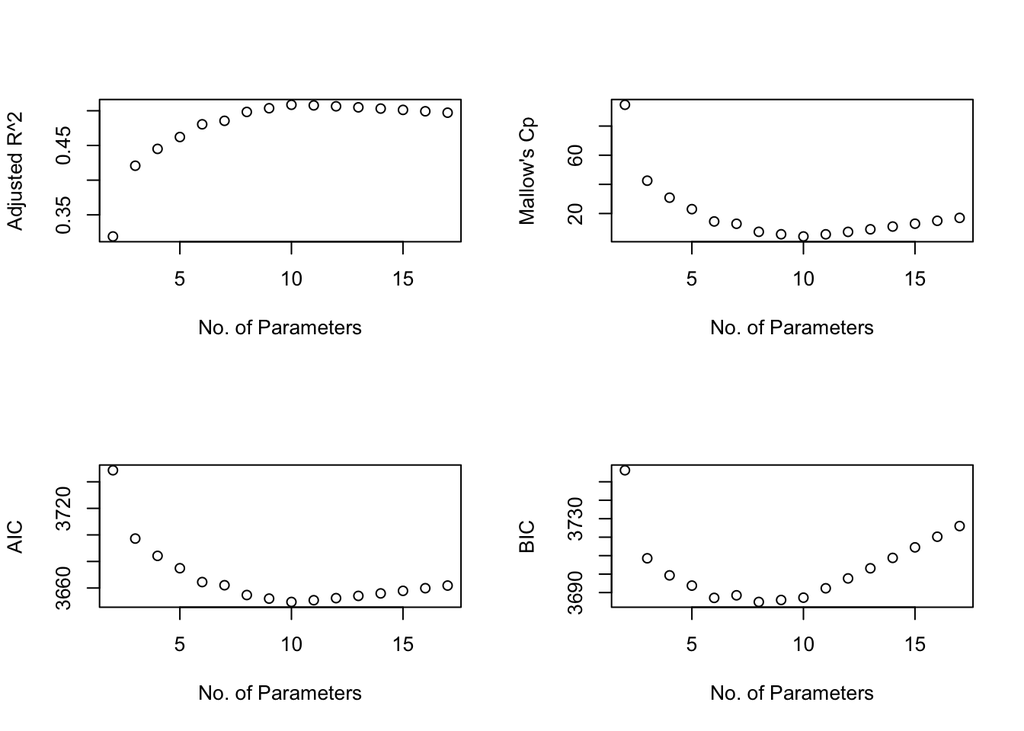

   ```r
   par(mfrow=c(2,2))
   plot(msize, summary(model.full)$adjr2, xlab="No. of Parameters", ylab = "Adjusted R^2")
   plot(msize, summary(model.full)$cp, xlab="No. of Parameters", ylab = "Mallow's Cp")
   Aic = n*log(summary(model.full)$rss/n) + 2*msize;
   plot(msize, Aic, xlab="No. of Parameters", ylab = "AIC");
   Bic = n*log(summary(model.full)$rss/n) + msize*log(n);
   plot(msize, Bic, xlab="No. of Parameters", ylab = "BIC")
   ```

   The highest adjusted $R^2$ is achieved with

   ```r
    which.max(summary(model.full)$adjr2)
   ```

   ```
   ## [1] 9
   ```

   This corresponds to a model with parameters

   ```r
    summary(model.full)$which[9,]
   ```

   ```
   ## (Intercept)       AtBat        Hits       HmRun        Runs         RBI
   ##        TRUE        TRUE        TRUE       FALSE       FALSE       FALSE
   ##       Walks       Years      CAtBat       CHits      CHmRun       CRuns
   ##        TRUE       FALSE        TRUE       FALSE       FALSE        TRUE
   ##        CRBI      CWalks     PutOuts     Assists      Errors
   ##        TRUE        TRUE        TRUE        TRUE       FALSE
   ```

   The minimum Mallow’s $C_p$ is achieved with

   ```r
    which.min(summary(model.full)$cp)
   ```

   ```
   ## [1] 9
   ```

   the minimum AIC with

   ```r
   which.min(Aic)
   ```

   ```
   ## [1] 9
   ```

   the minimum BIC with

   ```r
    which.min(summary(model.full)$bic)
   ```

   ```
   ## [1] 7
   ```

   This corresponds to a model with parameters

   ```r
    summary(model.full)$which[7,]
   ```

   ```
   ## (Intercept)       AtBat        Hits       HmRun        Runs         RBI
   ##        TRUE        TRUE        TRUE       FALSE       FALSE       FALSE
   ##       Walks       Years      CAtBat       CHits      CHmRun       CRuns
   ##        TRUE       FALSE       FALSE       FALSE        TRUE        TRUE
   ##        CRBI      CWalks     PutOuts     Assists      Errors
   ##       FALSE        TRUE        TRUE       FALSE       FALSE
   ```

2. We then use the function for model selection. Explain which variables are removed and in which order.

   ```r
   model.full.step = lm(Salary ~ ., data = Hitters)
   step(model.full.step, direction="backward", k=log(n))
   ```

   ```
   ## Start:  AIC=3114.52
   ## Salary ~ AtBat + Hits + HmRun + Runs + RBI + Walks + Years +
   ##     CAtBat + CHits + CHmRun + CRuns + CRBI + CWalks + PutOuts +
   ##     Assists + Errors
   ##
   ##           Df Sum of Sq      RSS    AIC
   ## - RBI      1         8 25170317 3108.8
   ## - CHits    1      1081 25171390 3108.8
   ## - CHmRun   1      2078 25172387 3108.8
   ## - Years    1      4433 25174743 3108.8
   ## - HmRun    1     12315 25182625 3108.9
   ## - Errors   1     43386 25213696 3109.2
   ## - Runs     1     49833 25220142 3109.3
   ## - CRBI     1    134116 25304426 3110.1
   ## - CAtBat   1    170220 25340529 3110.5
   ## - Assists  1    301143 25471453 3111.9
   ## - CRuns    1    469495 25639805 3113.6
   ## <none>                 25170309 3114.5
   ## - CWalks   1    583629 25753938 3114.8
   ## - Hits     1   1086647 26256957 3119.9
   ## - Walks    1   1143099 26313409 3120.4
   ## - AtBat    1   1227447 26397757 3121.3
   ## - PutOuts  1   1447981 26618290 3123.5
   ##
   ## Step:  AIC=3108.75
   ## Salary ~ AtBat + Hits + HmRun + Runs + Walks + Years + CAtBat +
   ##     CHits + CHmRun + CRuns + CRBI + CWalks + PutOuts + Assists +
   ##     Errors
   ##
   ##           Df Sum of Sq      RSS    AIC
   ## - CHits    1      1134 25171451 3103.0
   ## - CHmRun   1      2200 25172517 3103.0
   ## - Years    1      4456 25174774 3103.0
   ## - HmRun    1     28852 25199169 3103.3
   ## - Errors   1     43659 25213977 3103.4
   ## - Runs     1     52423 25222740 3103.5
   ## - CRBI     1    156597 25326915 3104.6
   ## - CAtBat   1    170268 25340585 3104.7
   ## - Assists  1    301232 25471550 3106.1
   ## - CRuns    1    477603 25647920 3107.9
   ```

   [output cut: 130 more lines]

   ```
   ## - AtBat    1   1538472 27195249 3082.9
   ## - Hits     1   1870968 27527744 3086.1
   ##
   ## Step:  AIC=3072.52
   ## Salary ~ AtBat + Hits + Walks + CRuns + CRBI + CWalks + PutOuts
   ##
   ##           Df Sum of Sq      RSS    AIC
   ## <none>                 26142464 3072.5
   ## - CRBI     1    661240 26803704 3073.3
   ## - CRuns    1    849739 26992202 3075.2
   ## - CWalks   1    868700 27011164 3075.3
   ## - PutOuts  1   1385532 27527996 3080.3
   ## - AtBat    1   1754846 27897310 3083.8
   ## - Walks    1   1825310 27967774 3084.5
   ## - Hits     1   2032384 28174847 3086.4
   ```

   ```
   ##
   ## Call:
   ## lm(formula = Salary ~ AtBat + Hits + Walks + CRuns + CRBI + CWalks +
   ##     PutOuts, data = Hitters)
   ##
   ## Coefficients:
   ## (Intercept)        AtBat         Hits        Walks        CRuns         CRBI
   ##     48.5758      -2.1906       7.4369       6.5329       0.7281       0.4862
   ##      CWalks      PutOuts
   ##     -0.7813       0.2779
   ```

   Starting with the full model, we remove first the variable `RBI`, since this is the way that we will get the smallest BIC. In the next steps we remove the following variables in order: `CHits`, `Years`, `CHmRun`, `HmRun`, `Errors`, `Runs`, `Assists`, and `CAtBat.`